# Lab 1: Monte Carlo Methods and Random Variable Generation

# Part 8: Multivariate Generation

## Exercise 8.1: Correlated Normal Variables

Generate bivariate normal with specified correlation.

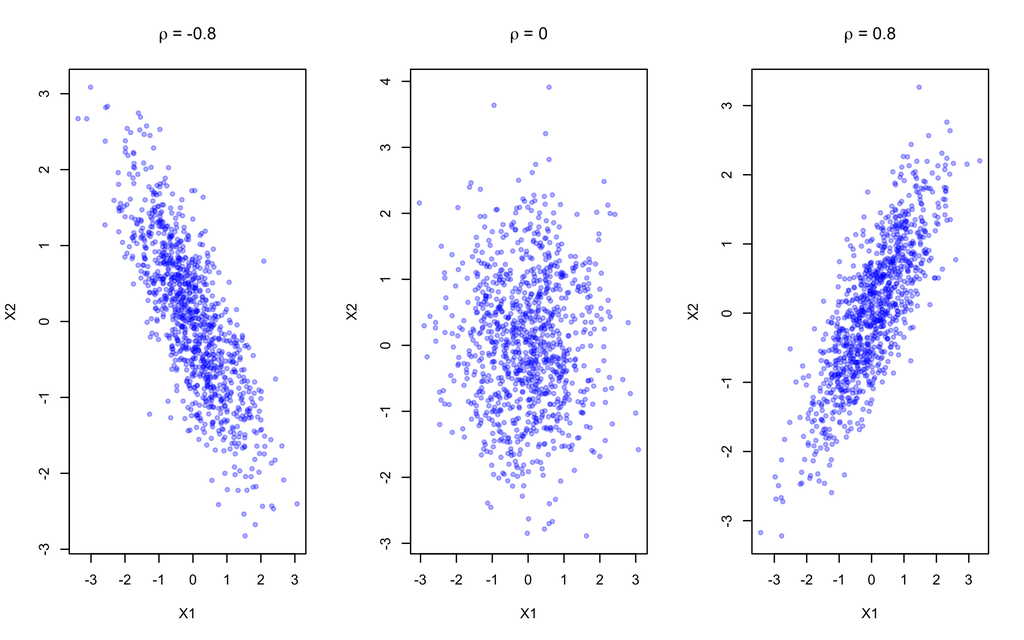

```r
set.seed(536)

# TODO: Generate correlated normals
rmvnorm_cholesky <- function(n, mu, Sigma) {
  # Your code here
  # Use Cholesky decomposition

  # PLACEHOLDER - Remove this and implement your solution
  d <- length(mu)
  L <- chol(Sigma)
  Z <- matrix(rnorm(n * d), nrow = n, ncol = d)
  X <- sweep(Z %*% L, 2, mu, "+")
  return(X)
}

# Test with different correlations
mu <- c(0, 0)
correlations <- c(-0.8, 0, 0.8)

par(mfrow = c(1, 3))
for (rho in correlations) {
  Sigma <- matrix(c(1, rho, rho, 1), 2, 2)
  samples <- rmvnorm_cholesky(1000, mu, Sigma)
  plot(samples, main = substitute(paste(rho, " = ", r), list(r = rho)),
       xlab = "X1", ylab = "X2", pch = 20, col = rgb(0, 0, 1, 0.3))
}
```

# Part 9: Integration Challenge

## Exercise 9.1: Joint Probability Estimation

Estimate P(X + Y > 3) where X ~ Gamma(2, 1), Y ~ Beta(3, 2).

```r
set.seed(536)

# TODO: Implement the complete solution
estimate_joint_probability <- function(n_samples = 10000) {
  # Your code here
  # 1. Generate X using sum of exponentials
  # 2. Generate Y using gamma ratio method
  # 3. Estimate probability with confidence interval

  # PLACEHOLDER - Remove this and implement your solution
  # Generate X ~ Gamma(2, 1) as sum of two Exp(1)
  X <- rexp(n_samples) + rexp(n_samples)

  # Generate Y ~ Beta(3, 2) using gamma ratio
  gamma1 <- rgamma(n_samples, shape = 3, rate = 1)
  gamma2 <- rgamma(n_samples, shape = 2, rate = 1)
  Y <- gamma1 / (gamma1 + gamma2)

  # Estimate probability
  prob <- mean((X + Y) > 3)
  se <- sqrt(prob * (1 - prob) / n_samples)
  ci <- prob + c(-1.96, 1.96) * se

  return(list(
    probability = prob,
    se = se,
    ci = ci
  ))
}

result <- estimate_joint_probability()
print(result)
```

```
$probability
[1] 0.3154

$se
[1] 0.00464675

$ci
[1] 0.3062924 0.3245076
```

# Part 10: Comprehensive Test Suite

Run all tests to check your implementations.

```r
# Automated testing suite
run_all_tests <- function() {
  print("Running all tests...")

  results <- list()

  # Test numerical stability
  results$ex1.1 <- test_exercise("1.1", function() {
    test_that("Log-sum-exp is stable", {
      expect_true(is.finite(log_sum_exp(c(-1000, -999))))
    })
  })

  # Test Monte Carlo integration
  results$ex2.1 <- test_exercise("2.1", function() {
    test_that("Pi estimation is accurate", {
      pi_est <- estimate_pi_mc(100000)
      expect_equal(pi_est, pi, tolerance = 0.01)
    })
  })

  # Test random variable generation
  results$ex5.1 <- test_exercise("5.1", function() {
    test_that("Weibull generation is correct", {
      samples <- rweibull_inverse(10000, shape = 2, scale = 1)
      ks_test <- ks.test(samples, pweibull, shape = 2, scale = 1)
      expect_true(ks_test$p.value > 0.01)
    })
  })

  # Summary
  passed <- sum(unlist(results))
  total <- length(results)

  print(sprintf("%d/%d tests passed", passed, total))

  return(results)
}

# Uncomment to run tests
# run_all_tests()
```

# Summary and Reflection

## Takeaways

1. **Numerical Stability**: Always use log-scale for probability computations
2. **Monte Carlo**: Error decreases as $O(1/\sqrt{n})$ regardless of dimension
3. **Validation**: Always validate your generators with Q-Q plots and statistical tests
4. **Efficiency**: Different methods have different computational costs

## Self-Assessment Questions

1. Why does the log-sum-exp trick work?
2. What is the theoretical convergence rate of Monte Carlo integration?
3. When would you use inverse transform vs. transformation methods?
4. How do you validate a random number generator?